# Cover-weighted trait models

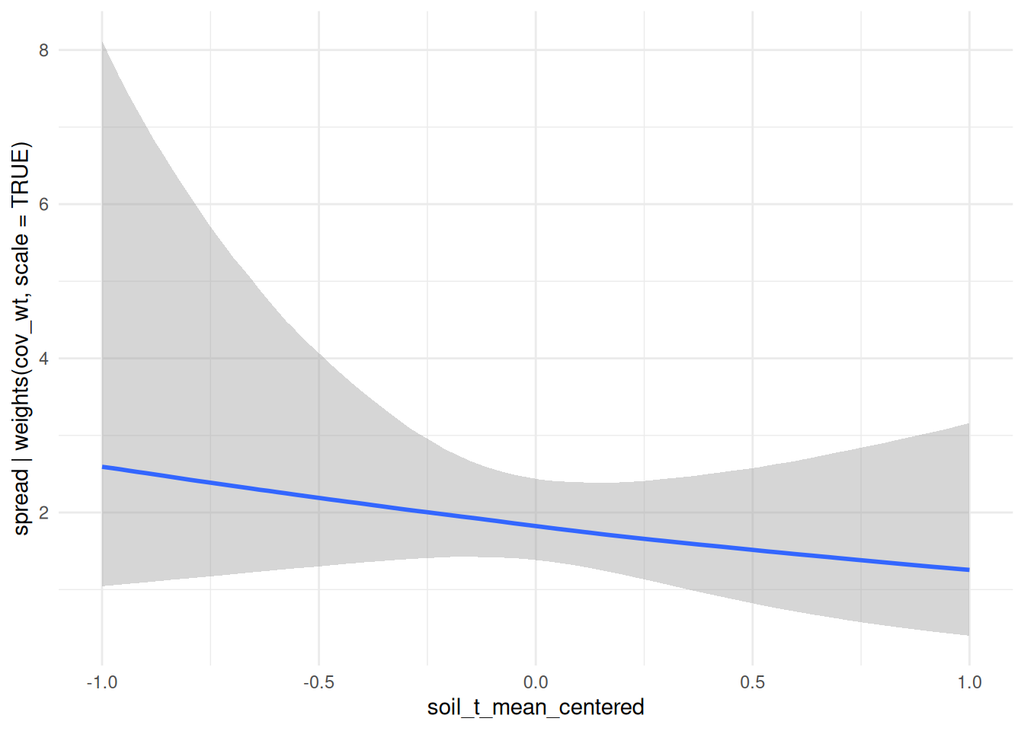

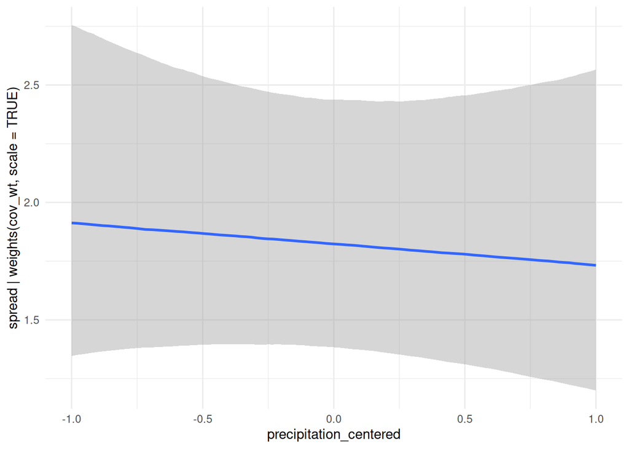

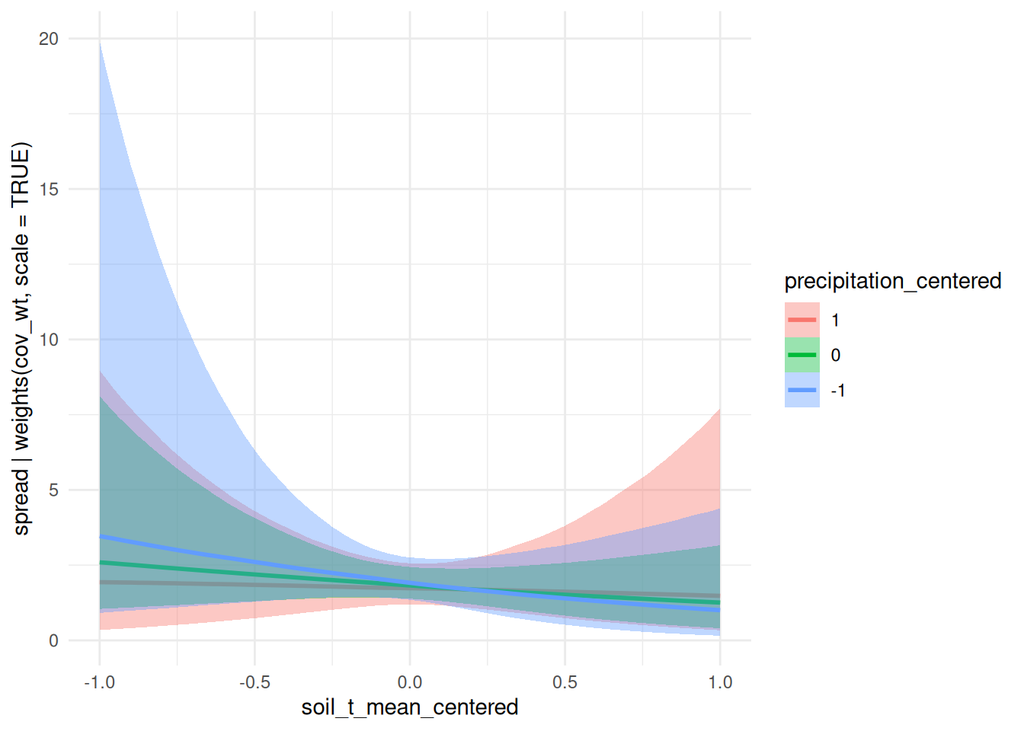

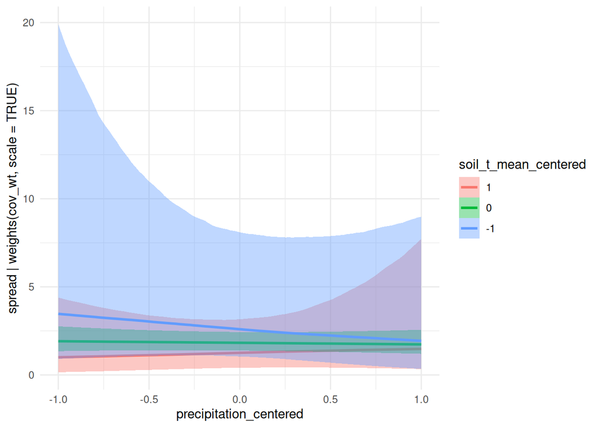

```r
my_ceffects(fit_spread_itp, hurdle = T)
```

## 5.10 Persistence

According to CLO-PLA “the data are effectively truncated by the value of 4 years, which should be interpreted as 4 years or more”. To correctly account for this in the model, persistence values of 4 are considered as right-censored. In practice, the results are substantially unaffected.

```r
fit_pers_itp <- brm_multiple(bf(persistence | weights(cov_wt, scale = TRUE) +
                                  cens(censored) ~
                                  soil_t_mean_centered + precipitation_centered +
                                  soil_t_mean_centered:precipitation_centered + cover + site,
                                hu ~ soil_t_mean_centered + precipitation_centered +
                                  soil_t_mean_centered:precipitation_centered + cover + site),
                             data = cwm_ITP$data$persistence |>
                               map(\(x) x |>
                                     mutate(censored = if_else(persistence * persistence_sd == 4, 1, 0))),
                             prior = prior_ln(cwm_ITP$data$persistence[[1]]$persistence, hu = T),
                             family = "hurdle_lognormal",
                             file = "fits/cwm/persistence.itp",
                             file_refit = "never",
                             init = 0,
                             control = list(seed = 2853))

prior_summary(fit_pers_itp)
```

| prior | class | coef | group | resp | dpar | nlpar | lb | ub | tag | source |
| --- | --- | --- | --- | --- | --- | --- | --- | --- | --- | --- |
| student_t(5, 0, 0.5) | b |  |  |  |  |  |  |  |  | user |
|  | b | cover |  |  |  |  |  |  |  | default |
|  | b | precipitation_centered |  |  |  |  |  |  |  | default |
|  | b | site1 |  |  |  |  |  |  |  | default |
|  | b | site2 |  |  |  |  |  |  |  | default |
|  | b | soil_t_mean_centered |  |  |  |  |  |  |  | default |
|  | b | soil_t_mean_centered:precipitation_centered |  |  |  |  |  |  |  | default |
| normal(0, 1) | b |  |  |  | hu |  |  |  |  | user |
|  | b | cover |  |  | hu |  |  |  |  | default |
|  | b | precipitation_centered |  |  | hu |  |  |  |  | default |
|  | b | site1 |  |  | hu |  |  |  |  | default |
|  | b | site2 |  |  | hu |  |  |  |  | default |
|  | b | soil_t_mean_centered |  |  | hu |  |  |  |  | default |
|  | b | soil_t_mean_centered:precipitation_centered |  |  | hu |  |  |  |  | default |
| student_t(3, 0.576, 0.6) | Intercept |  |  |  |  |  |  |  |  | user |
| logistic(0, 1) | Intercept |  |  |  | hu |  |  |  |  | default |
| student_t(5, 0, 0.5) | sigma |  |  |  |  |  | 0 |  |  | user |

```r
fit_pers_itp
```

```
 Family: hurdle_lognormal
  Links: mu = identity; hu = logit
Formula: persistence | weights(cov_wt, scale = TRUE) + cens(censored) ~ soil_t_mean_centered + precipitation_centered + soil_t_mean_centered:precipitation_centered + cover + site
         hu ~ soil_t_mean_centered + precipitation_centered + soil_t_mean_centered:precipitation_centered + cover + site
   Data: map(cwm_ITP$data$persistence, function(x) mutate(x (Number of observations: 373)
  Draws: 20 chains, each with iter = 2000; warmup = 1000; thin = 1;
         total post-warmup draws = 20000

Regression Coefficients:
                                               Estimate Est.Error l-95% CI
Intercept                                         -1.13      0.90    -2.94
hu_Intercept                                      -3.84      3.38   -10.51
soil_t_mean_centered                               0.00      0.27    -0.54
precipitation_centered                            -0.04      0.05    -0.13
cover                                              0.49      0.25     0.02
site1                                             -0.41      0.04    -0.50
site2                                              0.59      0.07     0.46
soil_t_mean_centered:precipitation_centered       -0.14      0.33    -0.79
hu_soil_t_mean_centered                            0.10      0.96    -1.80
hu_precipitation_centered                          0.05      0.39    -0.72
hu_cover                                           0.10      0.93    -1.72
hu_site1                                          -0.45      0.43    -1.35
hu_site2                                          -0.09      0.42    -0.95
hu_soil_t_mean_centered:precipitation_centered     0.01      0.97    -1.88
                                               u-95% CI
Intercept                                          0.59
hu_Intercept                                       2.76
soil_t_mean_centered                               0.55
precipitation_centered                             0.05
cover                                              0.99
site1                                             -0.33
site2                                              0.73
soil_t_mean_centered:precipitation_centered        0.52
hu_soil_t_mean_centered                            1.99
hu_precipitation_centered                          0.82
hu_cover                                           1.92
hu_site1                                           0.32
hu_site2                                           0.71
hu_soil_t_mean_centered:precipitation_centered     1.92

Further Distributional Parameters:
      Estimate Est.Error l-95% CI u-95% CI
sigma     0.46      0.02     0.42     0.51

Draws were sampled using sample(hmc). Overall Rhat and ESS estimates
are not informative for brm_multiple models and are hence not displayed.
Please see ?brm_multiple for how to assess convergence of such models.
```

```r
multiple_convergence(fit_pers_itp)
```

| variable | rhat | ess_bulk | ess_tail |
| --- | --- | --- | --- |
| b_Intercept | 1 | 2507 | 2643 |
| b_hu_Intercept | 1 | 4105 | 2750 |
| b_soil_t_mean_centered | 1 | 4207 | 2755 |
| b_precipitation_centered | 1 | 3821 | 2289 |
| b_cover | 1 | 2535 | 2656 |
| b_site1 | 1 | 2658 | 2337 |
| b_site2 | 1 | 2412 | 2338 |
| b_soil_t_mean_centered:precipitation_centered | 1 | 4049 | 2847 |
| b_hu_soil_t_mean_centered | 1 | 4992 | 2915 |
| b_hu_precipitation_centered | 1 | 4669 | 2469 |
| b_hu_cover | 1 | 4099 | 2749 |
| b_hu_site1 | 1 | 3658 | 2332 |
| b_hu_site2 | 1 | 3102 | 2666 |
| b_hu_soil_t_mean_centered:precipitation_centered | 1 | 4797 | 2782 |
| sigma | 1 | 3791 | 2610 |
| Intercept | 1 | 3839 | 2725 |
| Intercept_hu | 1 | 3980 | 2424 |

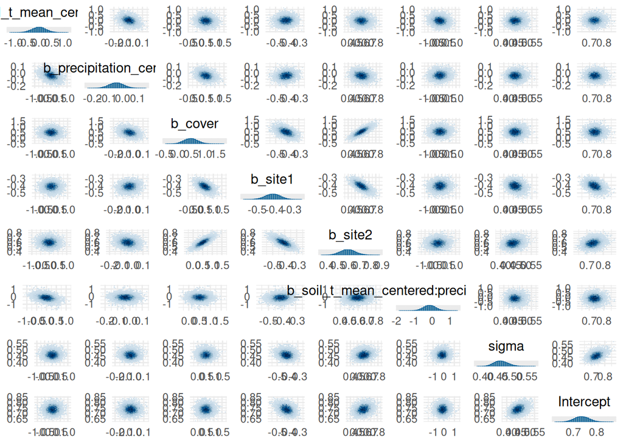

```r
my_mcmc_pairs(fit_pers_itp, vars(!contains(c("hu", "lp", "b_Intercept"))))
```

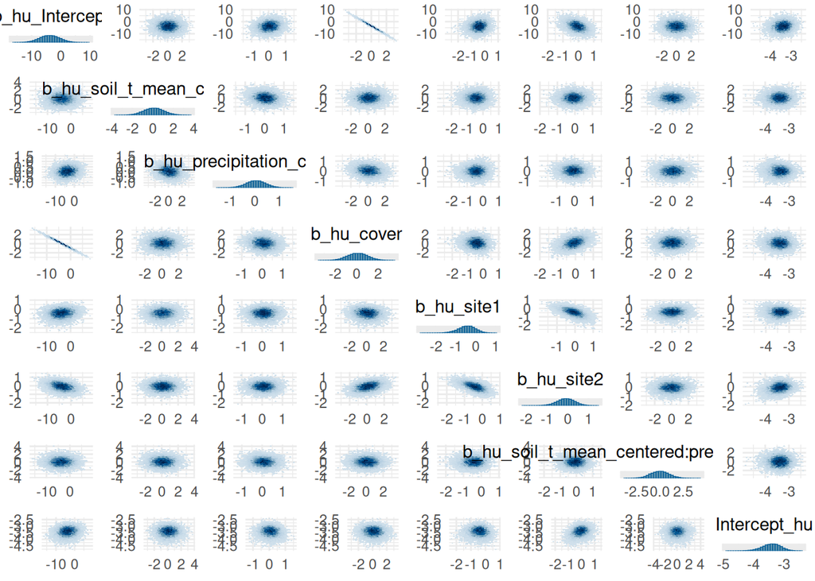

```r
my_mcmc_pairs(fit_pers_itp, pars = vars(contains("hu")))
```

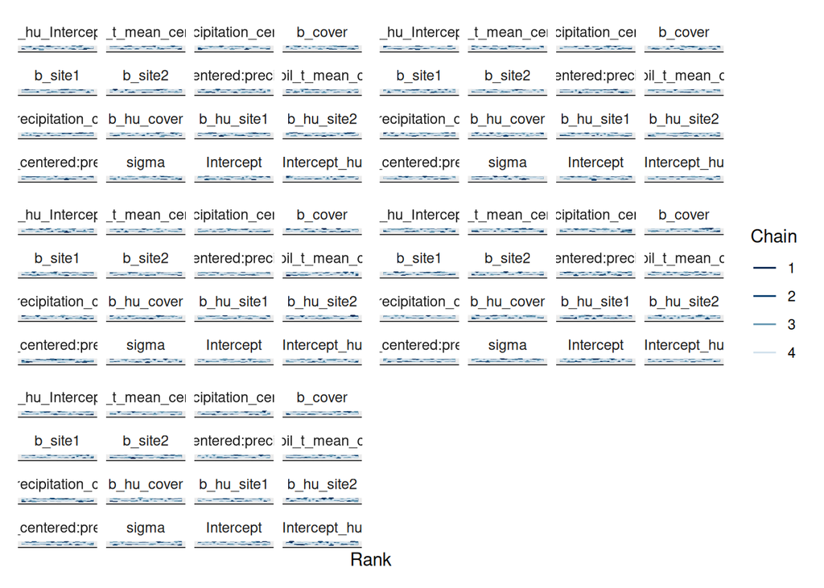

```r
trank(fit_pers_itp)
```

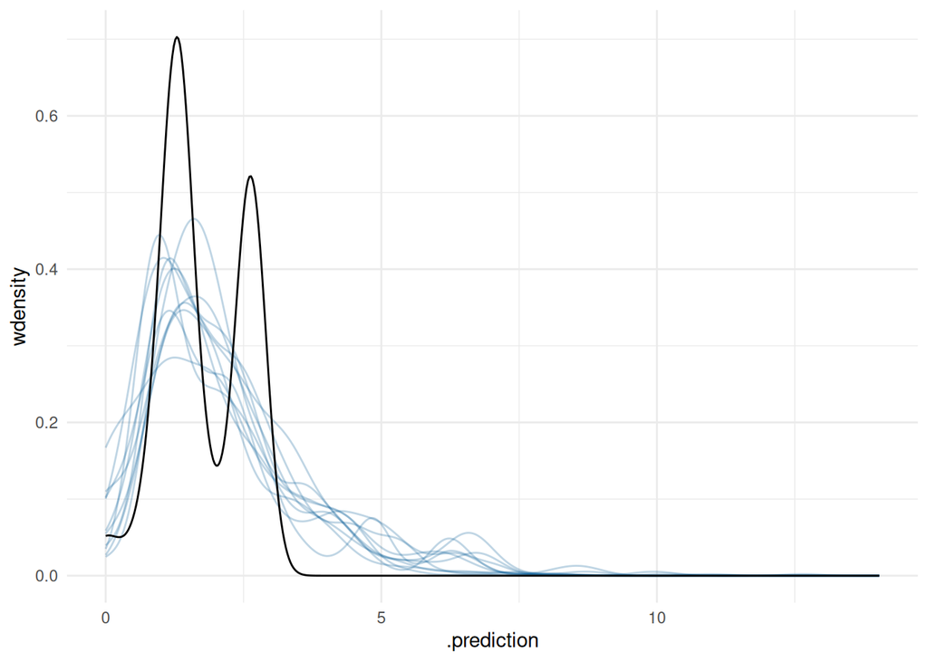

```r
my_ppc(fit_pers_itp, cwm_ITP$data$persistence, range = F)
```

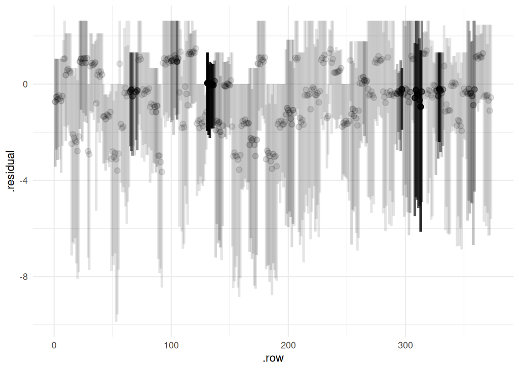

```r
#this plot may not be meaningful for censored models
my_resplot(fit_pers_itp, cwm_ITP$data$persistence[[1]])
```

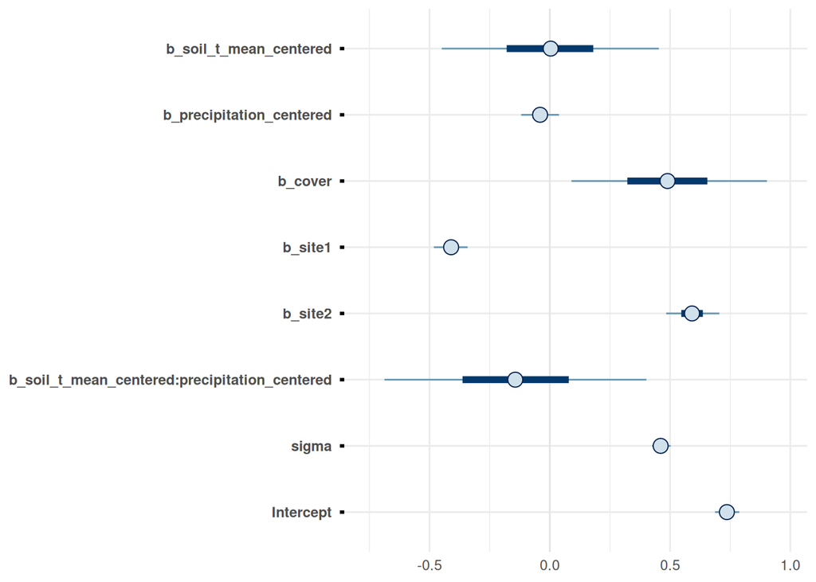

```r
mcmc_intervals(fit_pers_itp, pars = vars(!contains(c("hu", "lp", "b_Intercept"))))
```

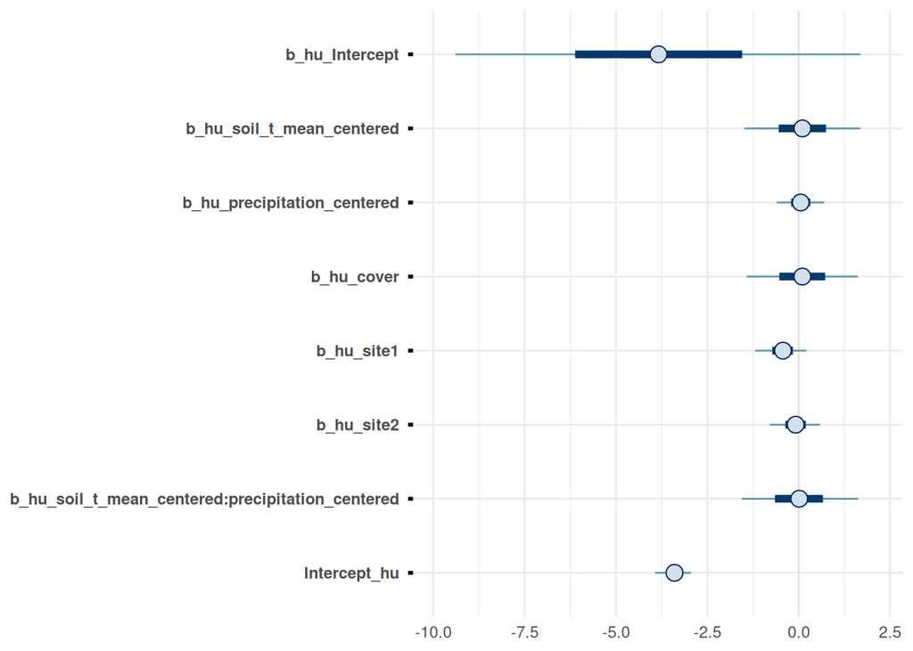

```r
mcmc_intervals(fit_pers_itp, pars = vars(contains("hu")))
```

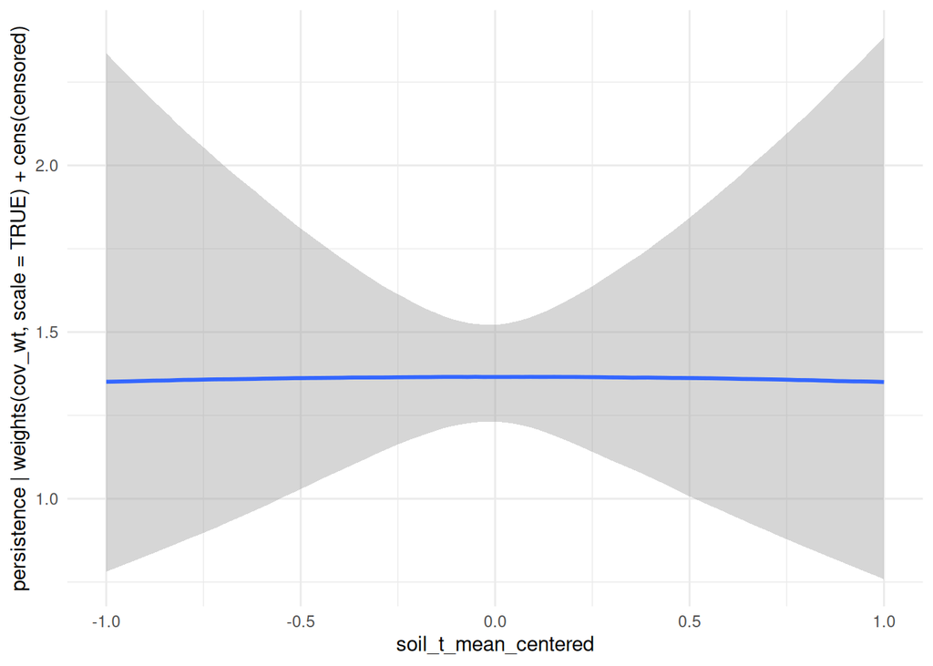

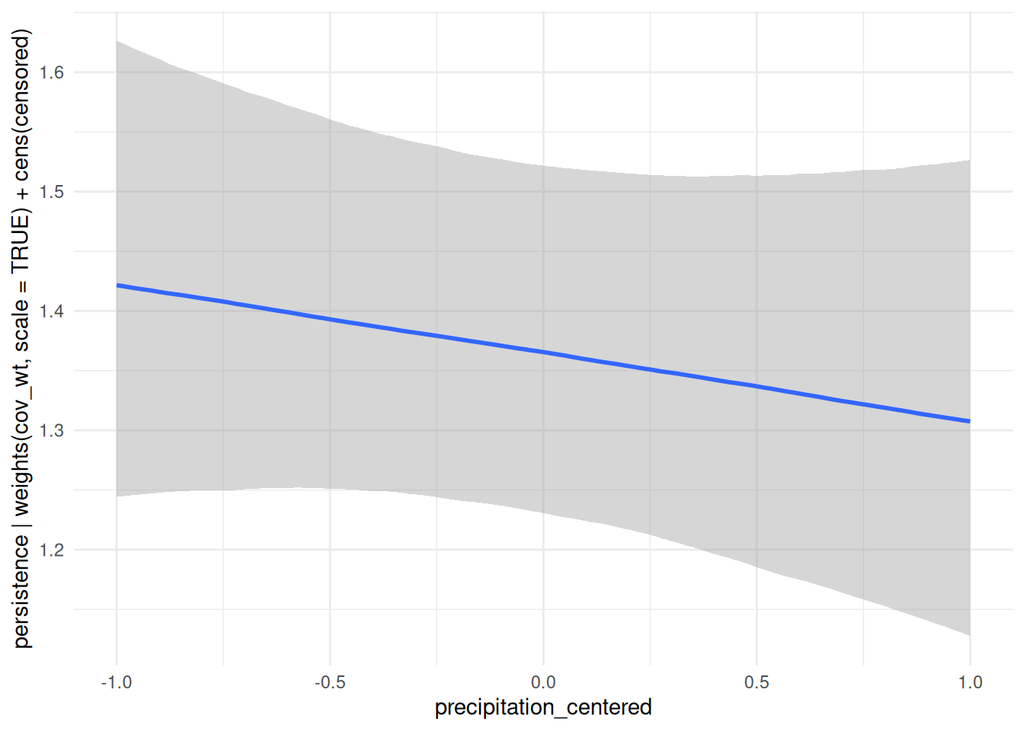

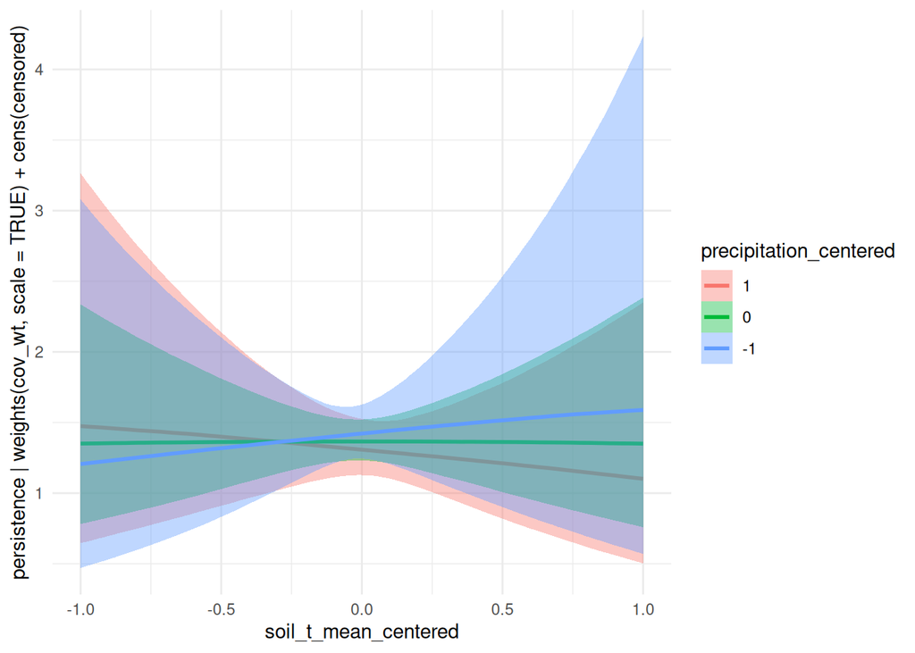

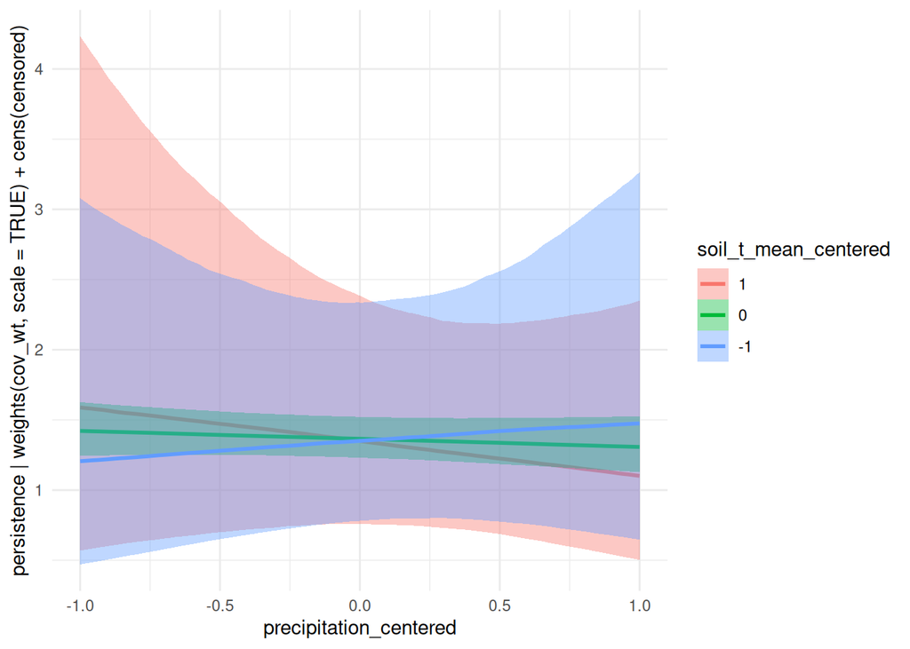

```r
my_ceffects(fit_pers_itp, hurdle = T)
```

# 6 Store fits

```r
#load brms fits
fits <- list.files("fits/cwm", pattern = "\\.rds$", full.names = T) |>
  map(readRDS) |>
  as_tibble_col(column_name = "fit")

#organize the models
fits <- fits |>
  mutate(name = list.files("fits/cwm", pattern = "\\.rds$") |>
           str_remove("\\.rds$") |>
           str_replace_all("\\.", "_"),
  trait = word(name, 1, sep = "_"),
  type = word(name, 2, sep = "_"))

#add data
fits <- fits |>
  left_join(cwm_ITP) |>
  #average across imputations
  mutate(data = map(data,
                    \(x) x |> map(\(t) t |>
                             mutate(obs_id = row_number())) |>
                         bind_rows(.id = "imp") |>
                         summarise(across(where(is.numeric), mean),
                                   .by = c(site, obs_id)) |>
                         select(!obs_id)))
```

# 7 Diagnostics

## 7.1 Check number of divergent transitions

```r
fits <- fits |>
    mutate(n_divergent = map_int(fit,
                   \(x) nuts_params(x) |>
                     filter(Parameter == "divergent__" & Value == 1) |>
                     nrow()))

fits |>
  select(!c(data, fit)) |>
  filter(n_divergent > 0)
```

| name | trait | type | n_divergent |
| --- | --- | --- | --- |

## 7.2 Pareto *k*

In a weighted regression, the Pareto *k* diagnostic can flag points as influential just because their weight is large, so it is not computed here.

# 8 Save results

```r
fits |>
  select(!n_divergent) |>
  saveRDS("intermediate/fits_cwm.rds")
```